# Hands on with Regularization and Tree based Model Ensemble

```r
housing_df = read.csv("housing.csv")[,-1]
## first column is Id so it can be removed
```

## Section 1. Data Cleaning

**1.** Take a summary of the data and explore the result. How many categorical and numerical variables are there in the dataset?

```r
summary(housing_df)
```

```
   MSSubClass      MSZoning          LotFrontage        LotArea          Street             Alley             LotShape         LandContour
 Min.   : 20.0   Length:1460        Min.   : 21.00   Min.   :  1300   Length:1460        Length:1460        Length:1460        Length:1460
 1st Qu.: 20.0   Class :character   1st Qu.: 59.00   1st Qu.:  7554   Class :character   Class :character   Class :character   Class :character
 Median : 50.0   Mode  :character   Median : 69.00   Median :  9478   Mode  :character   Mode  :character   Mode  :character   Mode  :character
 Mean   : 56.9                      Mean   : 70.05   Mean   : 10517
 3rd Qu.: 70.0                      3rd Qu.: 80.00   3rd Qu.: 11602
 Max.   :190.0                      Max.   :313.00   Max.   :215245
                                    NA's   :259
  Utilities          LotConfig          LandSlope         Neighborhood        Condition1         Condition2          BldgType          HouseStyle
 Length:1460        Length:1460        Length:1460        Length:1460        Length:1460        Length:1460        Length:1460        Length:1460
 Class :character   Class :character   Class :character   Class :character   Class :character   Class :character   Class :character   Class :character
 Mode  :character   Mode  :character   Mode  :character   Mode  :character   Mode  :character   Mode  :character   Mode  :character   Mode  :character




  OverallQual      OverallCond      YearBuilt     YearRemodAdd   RoofStyle           RoofMatl         Exterior1st        Exterior2nd
 Min.   : 1.000   Min.   :1.000   Min.   :1872   Min.   :1950   Length:1460        Length:1460        Length:1460        Length:1460
 1st Qu.: 5.000   1st Qu.:5.000   1st Qu.:1954   1st Qu.:1967   Class :character   Class :character   Class :character   Class :character
 Median : 6.000   Median :5.000   Median :1973   Median :1994   Mode  :character   Mode  :character   Mode  :character   Mode  :character
 Mean   : 6.099   Mean   :5.575   Mean   :1971   Mean   :1985
 3rd Qu.: 7.000   3rd Qu.:6.000   3rd Qu.:2000   3rd Qu.:2004
 Max.   :10.000   Max.   :9.000   Max.   :2010   Max.   :2010

  MasVnrType          MasVnrArea      ExterQual          ExterCond          Foundation          BsmtQual           BsmtCond         BsmtExposure
 Length:1460        Min.   :   0.0   Length:1460        Length:1460        Length:1460        Length:1460        Length:1460        Length:1460
 Class :character   1st Qu.:   0.0   Class :character   Class :character   Class :character   Class :character   Class :character   Class :character
 Mode  :character   Median :   0.0   Mode  :character   Mode  :character   Mode  :character   Mode  :character   Mode  :character   Mode  :character
                    Mean   : 103.7
                    3rd Qu.: 166.0
                    Max.   :1600.0
                    NA's   :8
 BsmtFinType1         BsmtFinSF1     BsmtFinType2         BsmtFinSF2        BsmtUnfSF       TotalBsmtSF       Heating           HeatingQC
 Length:1460        Min.   :   0.0   Length:1460        Min.   :   0.00   Min.   :   0.0   Min.   :   0.0   Length:1460        Length:1460
 Class :character   1st Qu.:   0.0   Class :character   1st Qu.:   0.00   1st Qu.: 223.0   1st Qu.: 795.8   Class :character   Class :character
 Mode  :character   Median : 383.5   Mode  :character   Median :   0.00   Median : 477.5   Median : 991.5   Mode  :character   Mode  :character
                    Mean   : 443.6                      Mean   :  46.55   Mean   : 567.2   Mean   :1057.4
                    3rd Qu.: 712.2                      3rd Qu.:   0.00   3rd Qu.: 808.0   3rd Qu.:1298.2
                    Max.   :5644.0                      Max.   :1474.00   Max.   :2336.0   Max.   :6110.0

```

[output cut: 24 more lines]

```
   WoodDeckSF      OpenPorchSF     EnclosedPorch      X3SsnPorch      ScreenPorch        PoolArea          PoolQC             Fence
 Min.   :  0.00   Min.   :  0.00   Min.   :  0.00   Min.   :  0.00   Min.   :  0.00   Min.   :  0.000   Length:1460        Length:1460
 1st Qu.:  0.00   1st Qu.:  0.00   1st Qu.:  0.00   1st Qu.:  0.00   1st Qu.:  0.00   1st Qu.:  0.000   Class :character   Class :character
 Median :  0.00   Median : 25.00   Median :  0.00   Median :  0.00   Median :  0.00   Median :  0.000   Mode  :character   Mode  :character
 Mean   : 94.24   Mean   : 46.66   Mean   : 21.95   Mean   :  3.41   Mean   : 15.06   Mean   :  2.759
 3rd Qu.:168.00   3rd Qu.: 68.00   3rd Qu.:  0.00   3rd Qu.:  0.00   3rd Qu.:  0.00   3rd Qu.:  0.000
 Max.   :857.00   Max.   :547.00   Max.   :552.00   Max.   :508.00   Max.   :480.00   Max.   :738.000

 MiscFeature           MiscVal             MoSold           YrSold       SaleType         SaleCondition        SalePrice
 Length:1460        Min.   :    0.00   Min.   : 1.000   Min.   :2006   Length:1460        Length:1460        Min.   : 34900
 Class :character   1st Qu.:    0.00   1st Qu.: 5.000   1st Qu.:2007   Class :character   Class :character   1st Qu.:129975
 Mode  :character   Median :    0.00   Median : 6.000   Median :2008   Mode  :character   Mode  :character   Median :163000
                    Mean   :   43.49   Mean   : 6.322   Mean   :2008                                         Mean   :180921
                    3rd Qu.:    0.00   3rd Qu.: 8.000   3rd Qu.:2009                                         3rd Qu.:214000
                    Max.   :15500.00   Max.   :12.000   Max.   :2010                                         Max.   :755000
```

```r
length(housing_df[,sapply(housing_df, is.character) == TRUE]) ## Number of categorical variables
```

```
[1] 43
```

```r
length(housing_df[,sapply(housing_df, is.numeric) == TRUE]) ## Number of numerical variables
```

```
[1] 37
```

**2.** (1pt) Which columns have missing values and what percentage of those columns have NAs? (Note. You can use colMeans(is.na(your data frame)) to find the percentage of NAs in each column).

```r
missing_vals_columns = which(colSums(is.na(housing_df)) > 0)
sort(colSums(sapply(housing_df[missing_vals_columns], is.na)), decreasing = TRUE)
```

```
      PoolQC  MiscFeature        Alley        Fence  FireplaceQu  LotFrontage   GarageType  GarageYrBlt GarageFinish   GarageQual   GarageCond BsmtExposure
        1453         1406         1369         1179          690          259           81           81           81           81           81           38
BsmtFinType2     BsmtQual     BsmtCond BsmtFinType1   MasVnrType   MasVnrArea   Electrical
          38           37           37           37            8            8            1
```

The above columns have missing values

```r
means = colMeans(sapply(housing_df[missing_vals_columns], is.na))
newmeans = as.numeric(sprintf("%2.3f", means)) * 100
names(newmeans) = names(means)
sort(newmeans, decreasing = TRUE)
```

```
      PoolQC  MiscFeature        Alley        Fence  FireplaceQu  LotFrontage   GarageType  GarageYrBlt GarageFinish   GarageQual   GarageCond BsmtExposure
        99.5         96.3         93.8         80.8         47.3         17.7          5.5          5.5          5.5          5.5          5.5          2.6
BsmtFinType2     BsmtQual     BsmtCond BsmtFinType1   MasVnrType   MasVnrArea   Electrical
         2.6          2.5          2.5          2.5          0.5          0.5          0.1
```

The above are the % NAs in each column with NAs

**3.** Is there any obvious outlier in the SalePrice? If so, remove them

```r
## Before transformation
str(housing_df$SalePrice)
```

```
 int [1:1460] 208500 181500 223500 140000 250000 143000 307000 200000 129900 118000 ...
```

```r
first_quant = quantile(housing_df$SalePrice)[2]
third_quant = quantile(housing_df$SalePrice)[4]
iqr = third_quant - first_quant
iqr_index = (housing_df$SalePrice > first_quant - 1.5*iqr & housing_df$SalePrice < third_quant + 1.5*iqr)
housing_df = housing_df[iqr_index, ]
## After transformation
str(housing_df$SalePrice)
```

```
 int [1:1399] 208500 181500 223500 140000 250000 143000 307000 200000 129900 118000 ...
```

**4.** (2pt)Read the data description carefully. For some of the variables, such as PoolQC, FirePlaceQU, Fence, etc. NA means not applicable rather than missing at random. For instance, a house that does not have a pool gets NA for PoolQC. For those variables for which NA means not applicable, you can replace NA with zero ( if that variable is numeric) or replace it with a new category/level, for instance, “notApplicable” if that variable is categorical.

```r
# Cleaning categorical variables
cat_columns = c("Alley","BsmtQual","BsmtCond","BsmtExposure","BsmtFinType1","BsmtFinType2","FireplaceQu","GarageType","GarageFinish","GarageQual","GarageCond","PoolQC","Fence","MiscFeature")
new_columns = lapply(cat_columns, function(x){
  housing_df[is.na(housing_df[,x]),x] <<- "notApplicable"
})

# Cleaning numerical variables
num_columns = (sapply(housing_df, is.numeric) == TRUE) & (colSums(is.na(housing_df)) > 0)
new_columns = lapply(names(housing_df[,num_columns]), function(x){
  housing_df[is.na(housing_df[,x]),x] <<- 0
})
```

**5.** (1pt) After replacing not applicable NAs with appropriate values, find out which columns still have NAs and what percentage of each column is missing.

```r
missing_vals_columns = which(colSums(is.na(housing_df)) > 0)
means = colMeans(sapply(housing_df[missing_vals_columns], is.na))
newmeans = as.numeric(sprintf("%2.3f", means)) * 100
names(newmeans) = names(means)
sort(newmeans, decreasing = TRUE)
```

```
MasVnrType Electrical
       0.5        0.1
```

**6.** (1pt) what percentage of rows in the dataset have one or more missing values? Use “complete.cases” function to answer this question.

```r
missing_count = length(which(!complete.cases(housing_df)))
as.numeric(sprintf("%2.3f",missing_count/1399)) * 100
```

```
[1] 0.6
```

0.6% of rows have missing values

## Section 2. Data Exploration

**8.** (1pt) plot the histogram of SalePrice. Interpret the histogram. Is SalePrice variable skewed? To replace SalePrice with log(SalePrice. Compare the histogram of salesprice before and after log transformation.

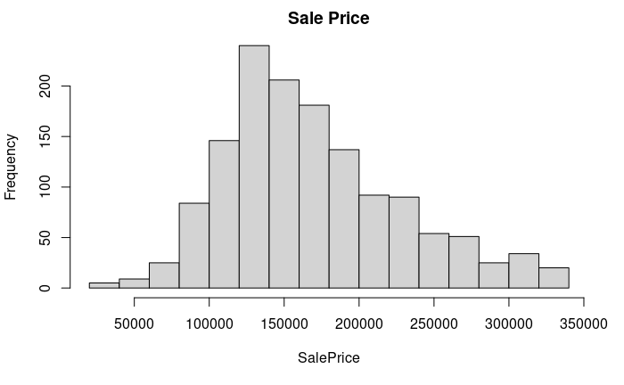

```r
hist(housing_df$SalePrice, xlab = "SalePrice", main = "Sale Price")
```

Yes, the SalePrice variable is right skewed

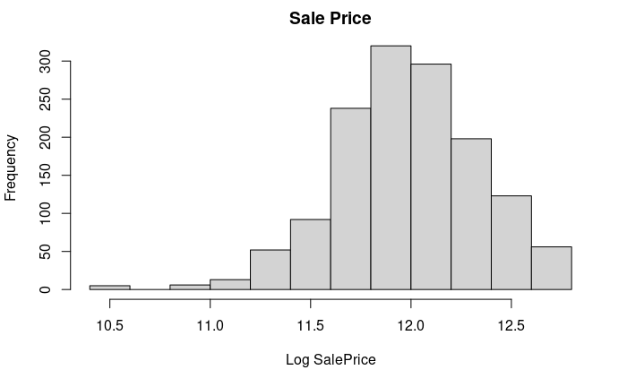

```r
hist(log(housing_df$SalePrice), xlab = "Log SalePrice", main = "Sale Price")
```

The histogram of Log SalePrice is left skewed.

**9.** (2 pt) Use plot (SalePrice~. , data=housing) (replace housing with your dataframe after data cleaning) to draw scatter and side by side box plots of other variables against the Sale Price. From these plots, what variables seem to have correlation with SalePrice? (Note since we have so many variables, you do not need to use statistics tests, you can just answer this question based on your observations of the plots)

```r
attach(housing_df)
```

The plots for categorical variables

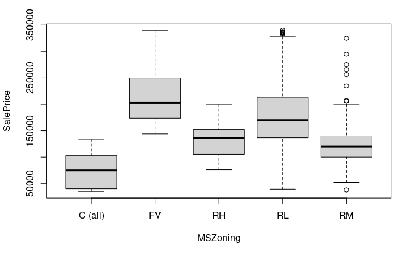

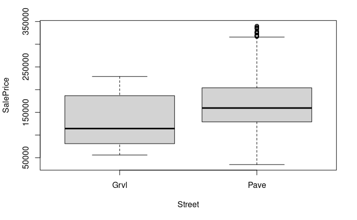

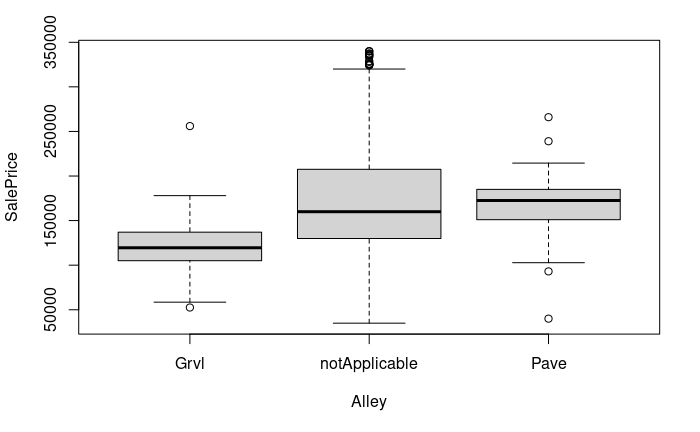

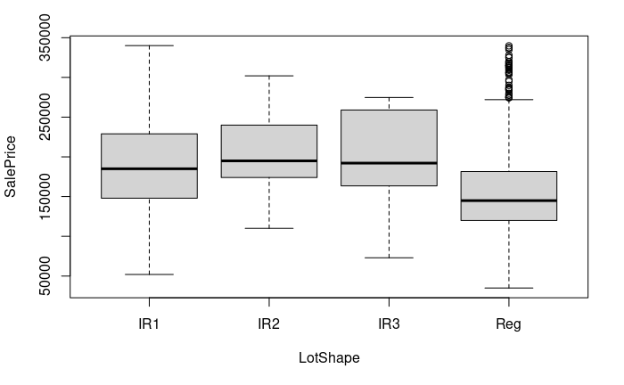

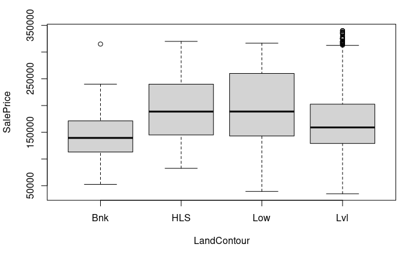

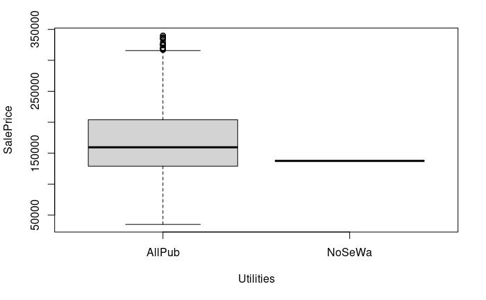

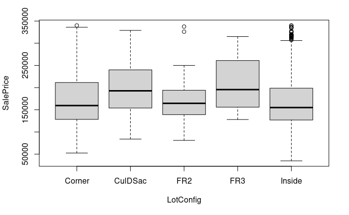

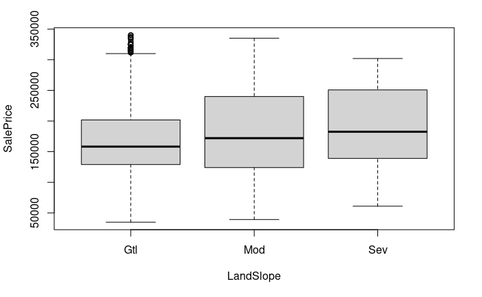

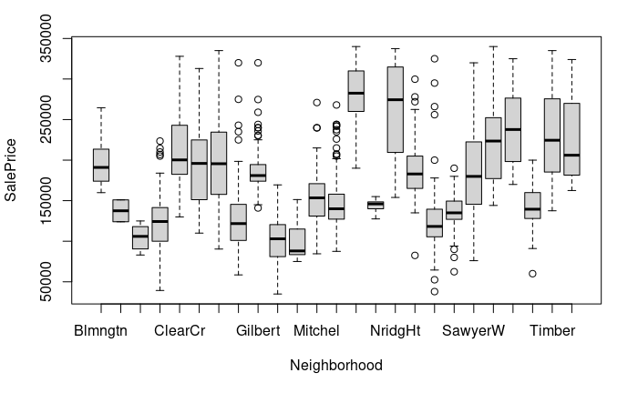

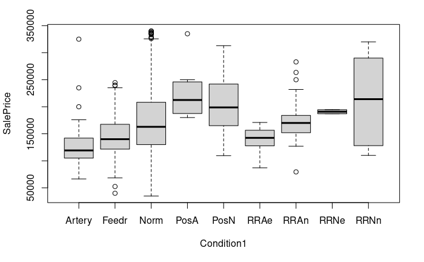

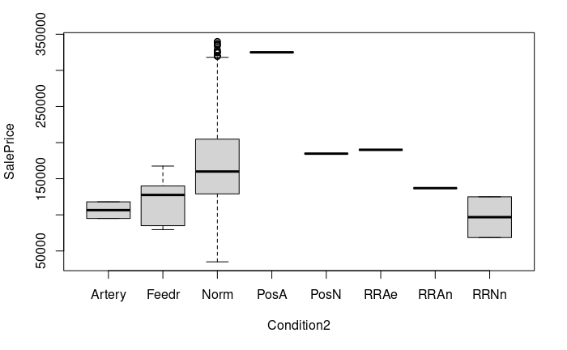

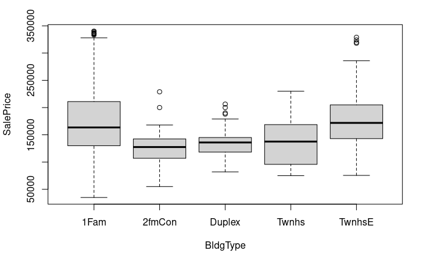

[31 more figures not shown]

```r
colName = names(housing_df)
temp = lapply(colName, function(col) {
  if (is.character(housing_df[,col])) {
      plot(SalePrice ~ as.factor(housing_df[,col]), xlab = col)
  }
  })
```

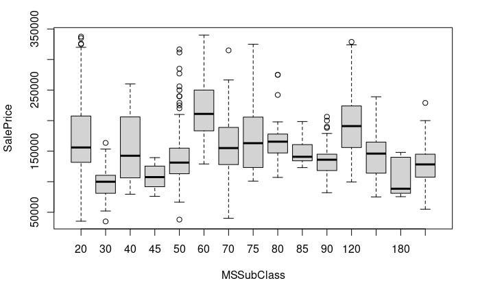

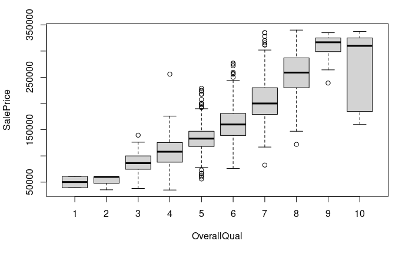

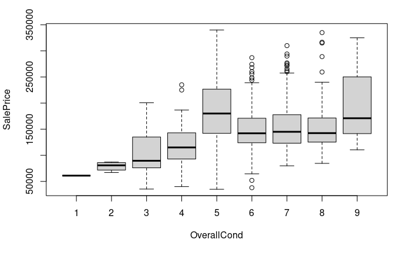

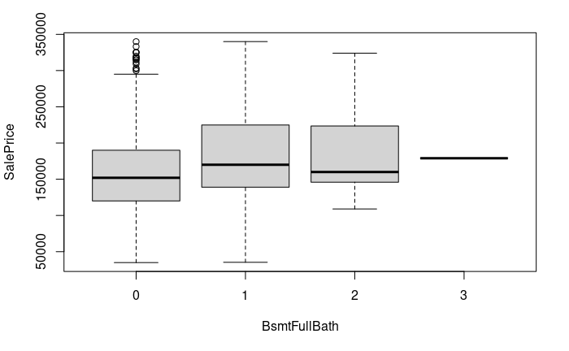

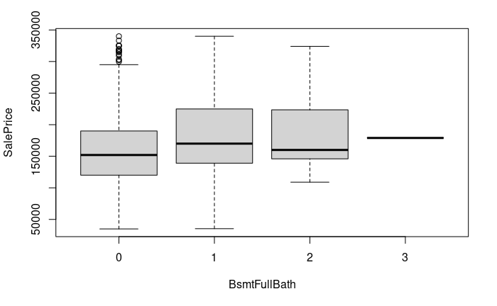

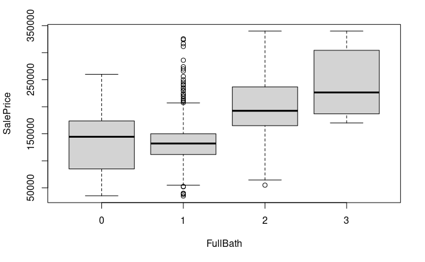

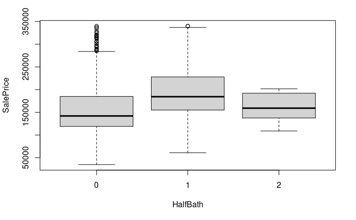

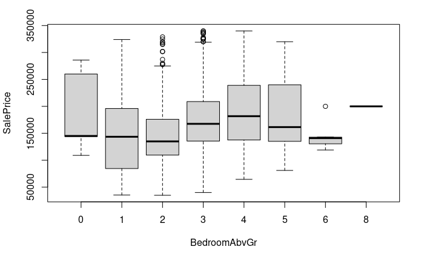

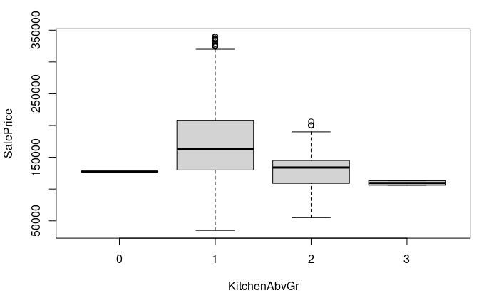

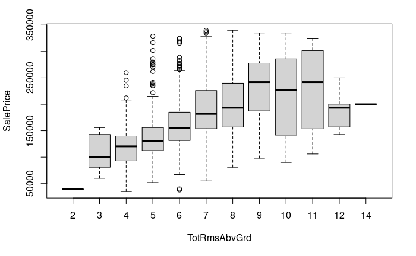

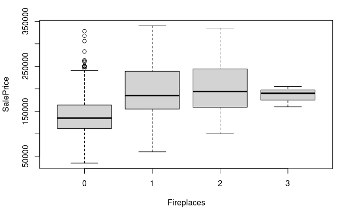

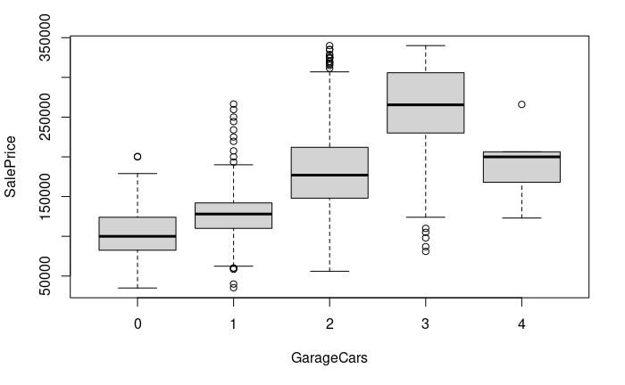

[2 more figures not shown]

```r
non_scatter = c("MSSubClass","OverallQual","OverallCond","BsmtFullBath","BsmtFullBath","FullBath","HalfBath","BedroomAbvGr","KitchenAbvGr","TotRmsAbvGrd","Fireplaces","GarageCars","MoSold","YrSold")

temp1 = lapply(non_scatter, function(col) {
      plot(SalePrice ~ as.factor(housing_df[,col]), xlab = col)
})
```

The scatter plots for numeric variables